# On the clumping of lottery serial numbers

Toni Giorgino

In the 2020 extraction of the Italian lottery, there was a “clump” of [3 almost-consecutive winning](https://milano.repubblica.it/cronaca/2020/01/07/news/lotteria_italia_ferno_varese_premi_biglietti_numeri_vicini-245177811/) serial numbers, namely P474343, P474346, P474348. This has raised suspicions.

**Q.** *How likely it is that such a clumping, or a stronger one, would arise given the null hypothesis that winning numbers are independent and uniformly probable, sampled without replacement?*

Let’s use a simple Monte-carlo (how apt) simulation to answer the question **Q**, which is of course framed as a Fisher-style null-hypothesis test.

The number of winners per year is $n=200$. The number of Lottery tickets sold in 2020 was approximately $N=6 \cdot 10^{6}$ [source needed].

To simplify the model, let’s assume that one extracts $n$ winning serial numbers out of a set $1...N$, without replacement.

Note that in reality serial numbers are not consecutive (e.g., blocks may be unsold, causing “breaks” in the sequence). The uniform-distribution we are assuming is a worst-case scenario (most likely to lead to clumps).

## Warmup: pair of “nearby” consecutive serials

As an exercise, let’s first compute the *distribution* of the minimum distance between two consecutive winning serial numbers.

```r
# Minimum distance between two lottery winning numbers, given
# that one extracts n winners out of a pool of N
mdist <- function(N=6e6, n=200) {
    w <- sort(sample(N,n))
    min(diff(w))
}

k <- 1:20
N <- 6e6
n <- 200

# The analytical solution of the warmup problem, Abramson and Moser, used later.
B <- function(k,n,p) {
    logB <- lfactorial(p-1) - (p-1)*log(n) + lchoose(n-p*(k-1)-1,
                                                     p-1)
    exp(logB)
}

set.seed(123)
```

Let’s simulate $R$ lotteries, i.e. replicate for $R=1000$ times.

```r
R <- 1000
md <- replicate(R,mdist())
```

The probabilities are now simply found by counting:

```r
# Probabilities that, under the null hypothesis,
# the minimum distance between two consecutive
# extractions was exactly 1, 2, ..., 20
u <- table(md)[1:20]/R
cu <- cumsum(u)
```

For readability, since we are interested in the probability of finding numbers at a distance of, say, 5 *or closer*, we use the cumulative distribution plot (black circles).

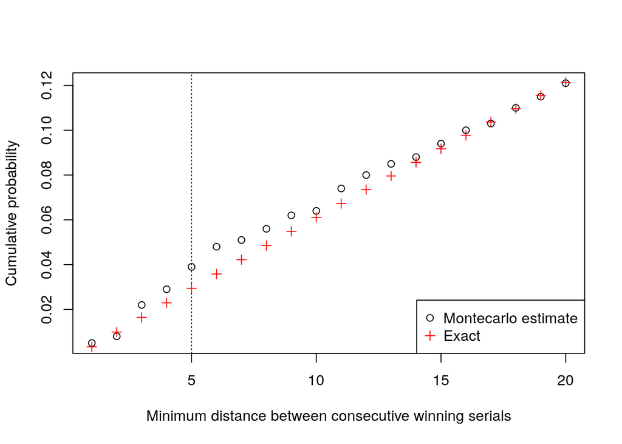

```r
plot(cu,
     xlab="Minimum distance between consecutive winning serials",
     ylab="Cumulative probability")
abline(v=5, lty=3)
points(k, 1-B(k, N, n), col=2, pch=3)
legend("bottomright",c("Montecarlo estimate","Exact"),pch=c(1,3),col=c(1,2))
```

So, a pair of serial numbers within, say, 5 of each other *or closer* is expected in approximately 3% of the lotteries, or once every 30. Note that since we are dealing with repeating tests (yearly extractions) it does not make sense to set a traditional $P$ threshold.

As a footnote, check out how this problem is related to the [birthday paradox](https://en.wikipedia.org/wiki/Birthday_problem) problem - with a similarly surprising outcome.

Abramson and Moser tackled a very similar problem in Abramson M, Moser WOJ. More Birthday Surprises. [The American Mathematical Monthly. 1970 Oct 1;77(8):856–8](https://www.tandfonline.com/doi/abs/10.1080/00029890.1970.11992600), where they provide an analytical expression for a very similar problem (in red).

## Solution: clumps of 3

If one is looking for clumps of 3 serial numbers close together (say, within a diameter of 5, as in the 2020 case), the calculation is surprisingly similar. We just need to compute the distance between the serial of $i$-th extracted winner, and the serial the $i+2$-th extracted winner (after sorting). A trivial modification to the code above yields:

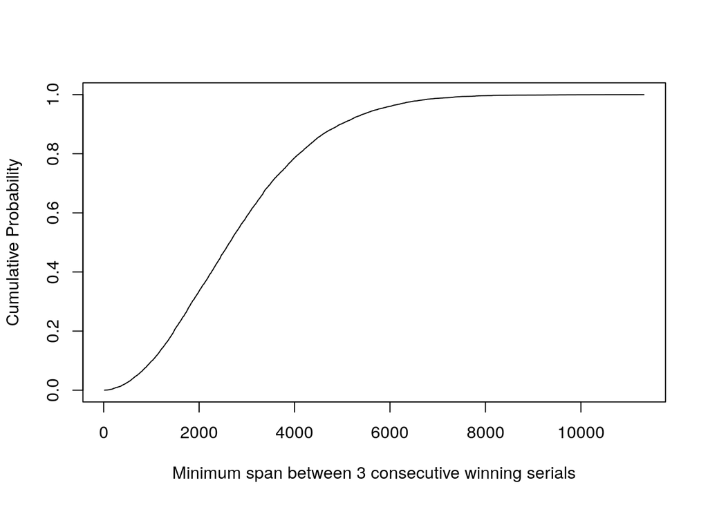

```r
# Minimum distance between C CONSECUTIVE lottery winning numbers, given that
# one extracts n winners out of a pool of N
mdistC <- function(N=6e6, n=200, C=3) {
    w <- sort(sample(N,n))
    min(diff(w, lag=C-1))
}

R <- 10000
md3 <- replicate(R,mdistC(C=3))

md3s <- sort(md3)
D <- (1:R)/R

plot(md3s, D, type="l",
     xlab="Minimum span between 3 consecutive winning serials",
     ylab="Cumulative Probability")
```

Now, that’s another story. The occurrences of 3-clumps are much sparser and, to gather sufficient statistics, we need to increase the number of replicas. Out of $R$ = 10^{4} replicates, the minimum “3-clumping diameter” were…

```r
md3s[1:10]
```

```
##  [1] 18 21 34 45 56 78 82 82 88 94
```

So not huge, but still far from the observed 5. To properly sample the final distribution at distances around 5, a separate notebook is provided to perform the same calculation in 10^6 replicates (using the Python language for speed, but the code is otherwise identical).

The result is that the probability to see a minimum 3-clump diameter of 5 or less is around 3 * 10^-6 per lottery.